# Example data sets

[Johan Koskinen](https://https://www.su.se/english/profiles/kosk-1.615440)

2026-03-15

## Intro

This is a script reading in a number of classic network data sets that we will use to investigate various random graph models. Most of this data is uploaded in raw text files on https://github.com/johankoskinen/CHDH-SNA/tree/main/data. If you want to download a data set outside of this vignette, navigate to the file you want, then press the *raw* button. This will open the file in a new tab. Alternatively, right-click on the the *raw* button and chose *save link as*.

Download data from GitHub

[figure not shown]

Files on GitHub repos

Make sure that you have loaded the required libraries.

```r
library("sna")
library("network")
```

### Tasks

For each network we read in, we will 1. Download it, 2. Format it, and 3. plot it, so that we can later work with them as well as calculating some summary statistics for the networks.

> All SNA should start with plotting your data and calculate basic summaries - if you can plot the network in `R` you can analyse it in `R`

## Padgett’s business network

This is an $n=16$ subset of the classic Padgett and Ansell (1993) Florentine families business network

```r
padgettbus <- as.matrix(read.table("https://raw.githubusercontent.com/johankoskinen/CHDH-SNA/main/data/PADGB.txt"))
gden(padgettbus)# using sna to calculate density of an adjacency matrix
```

```
## [1] 0.125
```

```r
padgbus.net <- as.network( padgettbus , directed=FALSE)# translate the matrix to a network object
padgbus.net
```

```
##  Network attributes:
##   vertices = 16
##   directed = FALSE
##   hyper = FALSE
##   loops = FALSE
##   multiple = FALSE
##   bipartite = FALSE
##   total edges= 15
##     missing edges= 0
##     non-missing edges= 15
##
##  Vertex attribute names:
##     vertex.names
##
## No edge attributes
```

The network is *undirected* and has a density of 12.5%

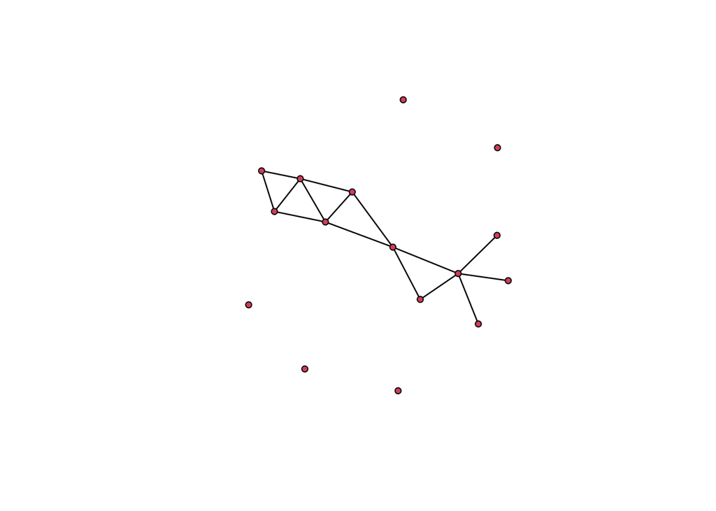

```r
plot( padgbus.net )
```

## Padgett’s marriage network

For the same $n=16$ subset of Florentine families, this is the marriage network

```r
padgettmar  <- as.matrix(read.table("https://raw.githubusercontent.com/johankoskinen/CHDH-SNA/main/data/PADGM.txt"))
gden(padgettmar)# using sna to calculate density of an adjacency matrix
```

```
## [1] 0.1666667
```

```r
padgmar.net <- as.network( padgettmar , directed=FALSE)# translate the matrix to a network object
padgmar.net
```

```
##  Network attributes:
##   vertices = 16
##   directed = FALSE
##   hyper = FALSE
##   loops = FALSE
##   multiple = FALSE
##   bipartite = FALSE
##   total edges= 20
##     missing edges= 0
##     non-missing edges= 20
##
##  Vertex attribute names:
##     vertex.names
##
## No edge attributes
```

The network is *undirected* and has a density of 16.7%

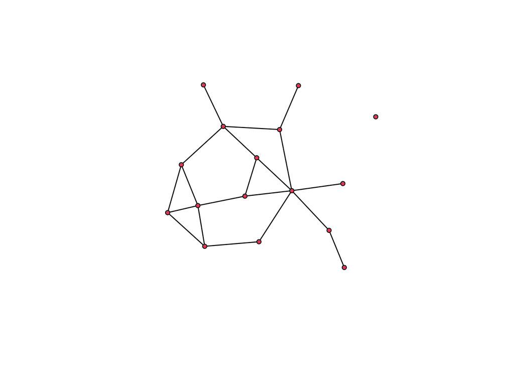

```r
plot( padgmar.net )
```

## Red Highland Tribes

A classic training data set, originally collected by Read (1954), is that of $n=16$ tribes of the Gahuku–Gama alliance structure of the Eastern Central Highlands of New Guinea and their positive and negative ties (Hage and Harary 1983).

```r
tribes.all  <- as.matrix(read.table("https://raw.githubusercontent.com/johankoskinen/CHDH-SNA/main/data/RedHighlandTribes.txt"))
tribesPos <- tribes.all[1:16,]# the first 16 lines are the positive ties
tribesNeg <-tribes.all[17:32,]# the bottomw 16 lines are the negative ties
gden(tribesPos)# using sna to calculate density of an adjacency matrix
```

```
## [1] 0.2416667
```

```r
gden(tribesNeg)# using sna to calculate density of an adjacency matrix
```

```
## [1] 0.2416667
```

```r
tribesPos.net <- as.network( tribesPos , directed=FALSE)# translate the matrix to a network object
tribesPos.net
```

```
##  Network attributes:
##   vertices = 16
##   directed = FALSE
##   hyper = FALSE
##   loops = FALSE
##   multiple = FALSE
##   bipartite = FALSE
##   total edges= 29
##     missing edges= 0
##     non-missing edges= 29
##
##  Vertex attribute names:
##     vertex.names
##
## No edge attributes
```

```r
tribesNeg.net <- as.network( tribesNeg , directed=FALSE)# translate the matrix to a network object
tribesNeg.net
```

```
##  Network attributes:
##   vertices = 16
##   directed = FALSE
##   hyper = FALSE
##   loops = FALSE
##   multiple = FALSE
##   bipartite = FALSE
##   total edges= 29
##     missing edges= 0
##     non-missing edges= 29
##
##  Vertex attribute names:
##     vertex.names
##
## No edge attributes
```

The networks are *undirected*

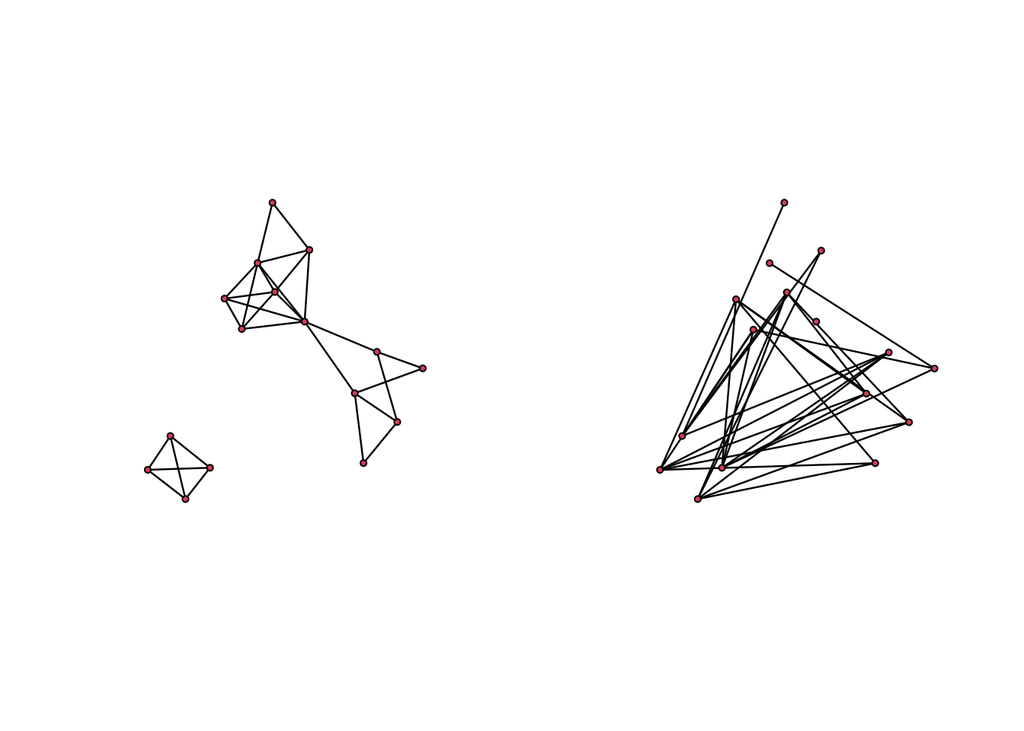

```r
par(mfrow=c(1,2))
coord <- plot( tribesPos.net )
plot( tribesNeg.net , coord=coord )
```

## Bank wiring room

Coming out of an extensive study by Mayo, Roethlisberger, and Dickson (1939), this dataset maps the ineractions among $n=14$ emplyoyes The interaction categories include: RDGAM, participation in horseplay; RDCON, participation in arguments about open windows; RDPOS, friendship; RDNEG, antagonistic (negative) behavior; RDHLP, helping others with work; and RDJOB, the number of times workers traded job assignments.

```r
wiring  <- as.matrix(read.table("https://raw.githubusercontent.com/johankoskinen/CHDH-SNA/main/data/bankwiring.txt"))

RDGAM <- wiring[1:14,]# RDGAM symmetric, binary, participation in horseplay
RDCON <- wiring[15:(2*14),]# RDCON symmetric, binary, participation in arguments about open windows
RDPOS <- wiring[(2*14+1):(3*14),]# RDPOS symmetric, binary,  friendship
RDNEG <- wiring[(3*14+1):(4*14),]# RDNEG symmetric, binary, antagonistic (negative) behavior

gden(RDGAM)# using sna to calculate density of an adjacency matrix
```

```
## [1] 0.3076923
```

```r
gden(RDCON)
```

```
## [1] 0.2087912
```

```r
gden(RDPOS)
```

```
## [1] 0.1428571
```

```r
gden(RDNEG)
```

```
## [1] 0.2087912
```

```r
RDGAM.net <- as.network( RDGAM , directed=FALSE)# translate the matrix to a network object
RDGAM.net
```

```
##  Network attributes:
##   vertices = 14
##   directed = FALSE
##   hyper = FALSE
##   loops = FALSE
##   multiple = FALSE
##   bipartite = FALSE
##   total edges= 28
##     missing edges= 0
##     non-missing edges= 28
##
##  Vertex attribute names:
##     vertex.names
##
## No edge attributes
```

```r
RDCON.net <- as.network( RDCON , directed=FALSE)# translate the matrix to a network object
RDCON.net
```

```
##  Network attributes:
##   vertices = 14
##   directed = FALSE
##   hyper = FALSE
##   loops = FALSE
##   multiple = FALSE
##   bipartite = FALSE
##   total edges= 19
##     missing edges= 0
##     non-missing edges= 19
##
##  Vertex attribute names:
##     vertex.names
##
## No edge attributes
```

```r
RDPOS.net <- as.network( RDPOS , directed=FALSE)# translate the matrix to a network object
RDPOS.net
```

```
##  Network attributes:
##   vertices = 14
##   directed = FALSE
##   hyper = FALSE
##   loops = FALSE
##   multiple = FALSE
##   bipartite = FALSE
##   total edges= 13
##     missing edges= 0
##     non-missing edges= 13
##
##  Vertex attribute names:
##     vertex.names
##
## No edge attributes
```

```r
RDNEG.net <- as.network( RDNEG , directed=FALSE)# translate the matrix to a network object
RDNEG.net
```

```
##  Network attributes:
##   vertices = 14
##   directed = FALSE
##   hyper = FALSE
##   loops = FALSE
##   multiple = FALSE
##   bipartite = FALSE
##   total edges= 19
##     missing edges= 0
##     non-missing edges= 19
##
##  Vertex attribute names:
##     vertex.names
##
## No edge attributes
```

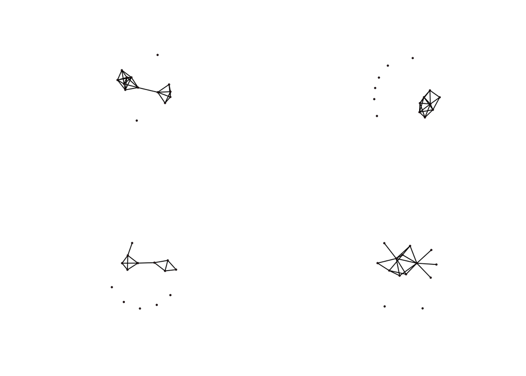

```r
par(mfrow=c(2,2))
plot( RDGAM.net )
plot( RDCON.net )
plot( RDPOS.net )
plot( RDNEG.net )
```

More details are found here http://moreno.ss.uci.edu/data.html#wiring.

## Zachary’s karate club

A network of $n=34$ members of a karate club (made famous as the testbed for community detection and blockmodelling algorithms) from the work of Zachary (1977)

```r
Zachary  <- as.matrix(read.table("https://raw.githubusercontent.com/johankoskinen/CHDH-SNA/main/data/zachary.txt"))

ZacharyBinary <- Zachary[1:34,]# symmetric, binary, positive
gden(ZacharyBinary)
```

```
## [1] 0.1390374
```

```r
ZacharyBinary.net <- as.network( ZacharyBinary , directed=FALSE)# translate the matrix to a network object
ZacharyBinary.net
```

```
##  Network attributes:
##   vertices = 34
##   directed = FALSE
##   hyper = FALSE
##   loops = FALSE
##   multiple = FALSE
##   bipartite = FALSE
##   total edges= 78
##     missing edges= 0
##     non-missing edges= 78
##
##  Vertex attribute names:
##     vertex.names
##
## No edge attributes
```

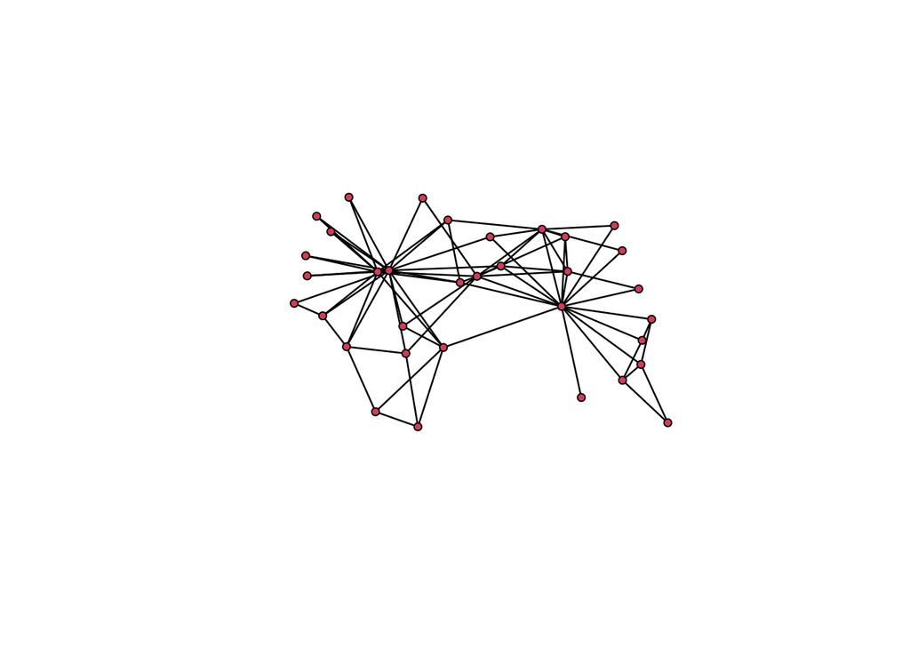

```r
plot( ZacharyBinary.net )
```

## Sageman’s Terrorist data

This is a dataset orignally provided by Sageman (Sageman 2011). Here it is in augmented form used in J. H. Koskinen et al. (2013). The ties are undirected and there are $n=366$ nodes

```r
SagemanAdjacencyMatrix  <- read.csv("https://raw.githubusercontent.com/johankoskinen/CHDH-SNA/main/data/sagemanAdjacency.csv",header=FALSE)# this is a comma separated csv
SagemanAdjacencyMatrix  <- as.matrix(SagemanAdjacencyMatrix[1:366,1:366])

gden(SagemanAdjacencyMatrix)
```

```
## [1] 0.01763605
```

```r
sage.net <- as.network( SagemanAdjacencyMatrix , directed=FALSE)# translate the matrix to a network object
sage.net
```

```
##  Network attributes:
##   vertices = 366
##   directed = FALSE
##   hyper = FALSE
##   loops = FALSE
##   multiple = FALSE
##   bipartite = FALSE
##   total edges= 1178
##     missing edges= 0
##     non-missing edges= 1178
##
##  Vertex attribute names:
##     vertex.names
##
##  Edge attribute names not shown
```

We can add some attributes

```r
SagemanAtt  <- read.csv("https://raw.githubusercontent.com/johankoskinen/CHDH-SNA/main/data/sageAttributes.csv",header=FALSE)# this is a comma separated csv

head(SagemanAtt)
```

```
##   V1          V2                        V3                               V4
## 1 ID  Short Name                 Full Name                            Alias
## 2  1   bin Laden           Osama bin Laden                     Abu Abdullah
## 3  2    Zawahiri         Ayman al-Zawahiri              Abdel Muiz, Dr. Nur
## 4  3    Banshiri   Ali Amin Ali al-Rashidi          Abu Ubaydah al-Banshiri
## 5  4      M Atef Subhi Mohammed abu Sittah Abu Hafs al-Masri, Mohammed Atef
## 6  5 Sheikh Omar  Sheikh Omar Abdel Rahman
##              V5             V6    V7                    V8         V9
## 1 Date of birth Place of birth Clump Youth National Status Family SES
## 2          1957             27     1                     2          1
## 3          1951             10     1                     1          1
## 4          9999             10     1                     1          2
## 5          1957             10     1                     1          2
## 6          1938             10     1                     1          3
##                    V10    V11                     V12               V13
```

[output cut: 20 more lines]

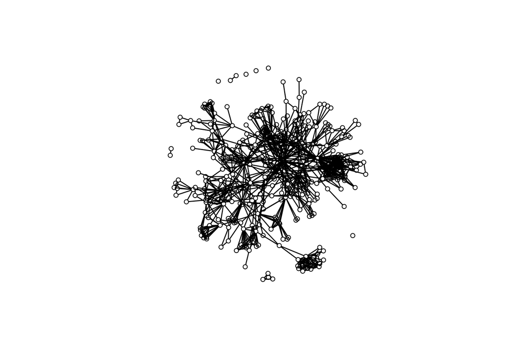

```r
plot( sage.net, vertex.col=SagemanAtt$Place.joined.the.jihad )
```

## Greek bombers

This is a network of members of the Revolutionary Organization 17 November group. We use the format as described in J. Koskinen et al. (2018).

```r
greekBomb  <- as.matrix(read.table("https://raw.githubusercontent.com/johankoskinen/CHDH-SNA/main/data/greekAdjacent.txt"))

gden(greekBomb)
```

```
## [1] 0.2973856
```

```r
greekBomb.net <- as.network( greekBomb , directed=FALSE)# translate the matrix to a network object
greekBomb.net
```

```
##  Network attributes:
##   vertices = 18
##   directed = FALSE
##   hyper = FALSE
##   loops = FALSE
##   multiple = FALSE
##   bipartite = FALSE
##   total edges= 46
##     missing edges= 0
##     non-missing edges= 46
##
##  Vertex attribute names:
##     vertex.names
##
## No edge attributes
```

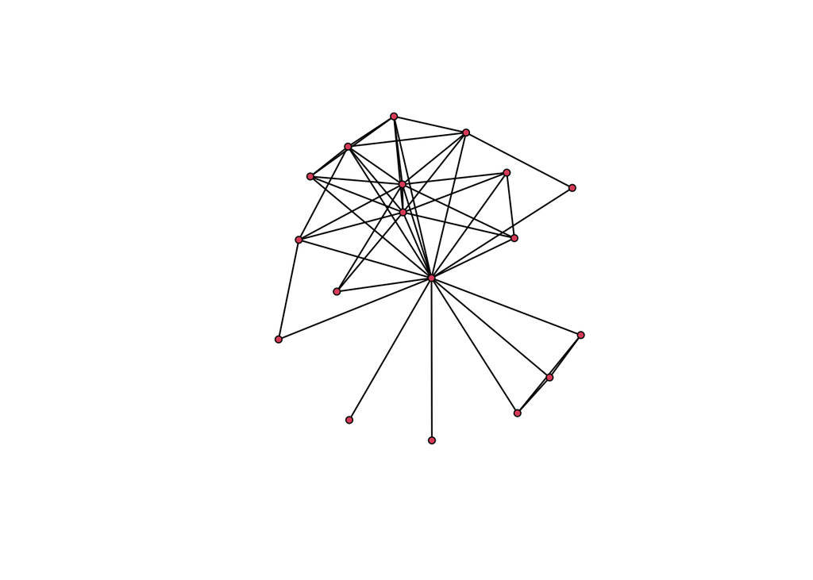

```r
plot( greekBomb.net )
```

## Webster

```r
Webster  <- as.matrix(read.table("https://raw.githubusercontent.com/johankoskinen/CHDH-SNA/main/data/WebsterSymmetricSocial.txt"))
# symmetrised version of REPORTED_SOCIAL non-symmetric, valued

gden(Webster)
```

```
## [1] 0.4384058
```

```r
Webster.net <- as.network( Webster , directed=FALSE)# translate the matrix to a network object
Webster.net
```

```
##  Network attributes:
##   vertices = 24
##   directed = FALSE
##   hyper = FALSE
##   loops = FALSE
##   multiple = FALSE
##   bipartite = FALSE
##   total edges= 121
##     missing edges= 0
##     non-missing edges= 121
##
##  Vertex attribute names:
##     vertex.names
##
## No edge attributes
```

Load some attributes as well

```r
WebsterAtt   <- read.table("https://raw.githubusercontent.com/johankoskinen/CHDH-SNA/main/data/WebsterAtt.txt")
# WebsterAtt.txt: One 24×2 matrix:
# Column 1, sex (1 = male. 2 = female
# Column 2, job (1 = Partner, 2 = Manager, 3 = Accountant, 4 = Staff member
head(WebsterAtt)
```

```
##   V1 V2
## 1  1  1
## 2  1  1
## 3  1  1
## 4  2  3
## 5  2  3
## 6  1  2
```

```r
vertex.sides <- matrix(50,dim(WebsterAtt)[1],1)# to use for plotting
vertex.sides[WebsterAtt[,1]==2] <- 4# females will be square
```

Plot

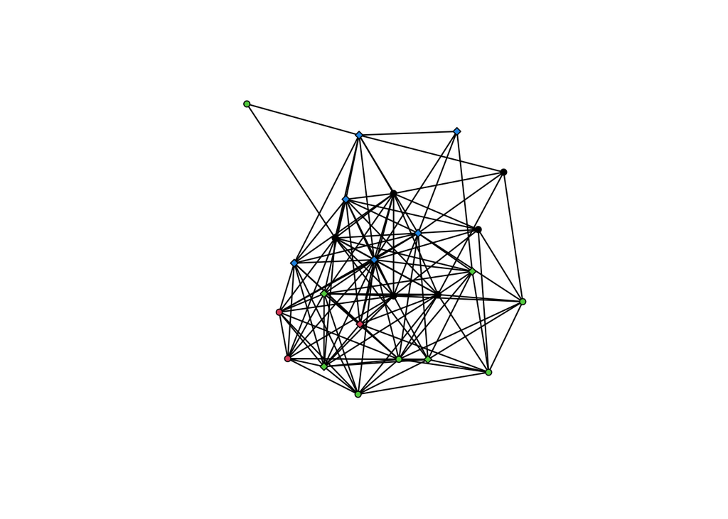

```r
plot( Webster.net, vertex.col=WebsterAtt[,2] , vertex.sides =vertex.sides)
```

## Noordin top

These data were drawn primarily from the International Crisis Group (2006) by Everton (Everton 2012) and include relational data on the $n=79$ individuals. For the person to person network we have used agrregate relations as in J. Koskinen et al. (2017).

```r
Noordin <- as.matrix( read.csv("https://raw.githubusercontent.com/johankoskinen/CHDH-SNA/main/data/everton.csv",
                               header=FALSE) )# this is a comma separated csv
gden(Noordin)
```

```
## [1] 0.1418371
```

```r
Noordin.net <- as.network( Noordin , directed=FALSE)# translate the matrix to a network object
Noordin.net
```

```
##  Network attributes:
##   vertices = 79
##   directed = FALSE
##   hyper = FALSE
##   loops = FALSE
##   multiple = FALSE
##   bipartite = FALSE
##   total edges= 437
##     missing edges= 0
##     non-missing edges= 437
##
##  Vertex attribute names:
##     vertex.names
##
## No edge attributes
```

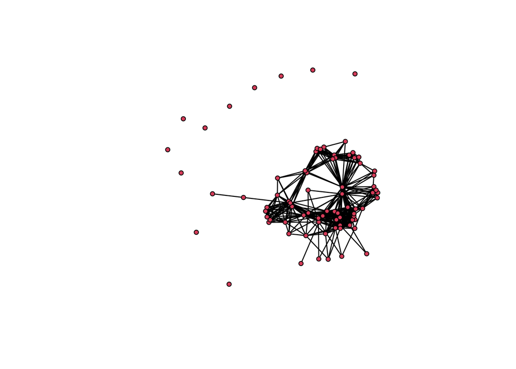

```r
plot( Noordin.net )
```

## Kapferer’s tailors

Kapferer (1972) studied a group of tailors in Zambia and collected a number of networks for the $n=39$ individuals.

```r
kapf  <- as.matrix(read.table("https://raw.githubusercontent.com/johankoskinen/CHDH-SNA/main/data/kapferer.txt"))
# "sociational" (friendship, socioemotional) interactions.
KAPFTS1 <- kapf[1:39,]#KAPFTS1 symmetric, binary: time 1
KAPFTS2 <- kapf[40:(2*39),]#KAPFTS2 symmetric, binary: time 2
KAPFTS1.net <- as.network( KAPFTS1 ,directed=FALSE)
KAPFTS2.net <-  as.network( KAPFTS2 ,directed=FALSE)
KAPFTS1.net
```

```
##  Network attributes:
##   vertices = 39
##   directed = FALSE
##   hyper = FALSE
##   loops = FALSE
##   multiple = FALSE
##   bipartite = FALSE
##   total edges= 158
##     missing edges= 0
##     non-missing edges= 158
##
##  Vertex attribute names:
##     vertex.names
##
## No edge attributes
```

```r
KAPFTS2.net
```

```
##  Network attributes:
##   vertices = 39
##   directed = FALSE
##   hyper = FALSE
##   loops = FALSE
##   multiple = FALSE
##   bipartite = FALSE
##   total edges= 223
##     missing edges= 0
##     non-missing edges= 223
##
##  Vertex attribute names:
##     vertex.names
##
## No edge attributes
```

The networks are *undirected*

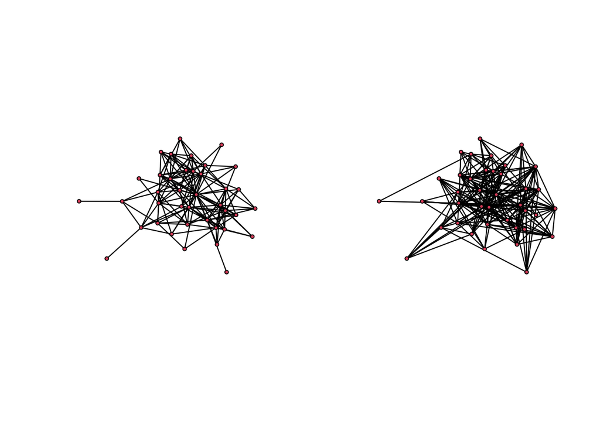

```r
par(mfrow=c(1,2))
coord <- plot( KAPFTS1.net )
plot( KAPFTS2.net , coord=coord )
```

## EIES

The Electronic Information Exchange System (EIES) data were collected by Linton Freeman. The codes 1-4 have the following meanings. 1. do not know the other 2. heard about the other, did not meet him/her 3. have met the other 4. friend.

We will only use friend.

```r
EIES1  <- as.matrix(read.table("https://raw.githubusercontent.com/johankoskinen/CHDH-SNA/main/data/EIES.1.txt",header=FALSE))
EIES2  <- as.matrix(read.table("https://raw.githubusercontent.com/johankoskinen/CHDH-SNA/main/data/EIES.2.txt",header=FALSE))

EIES1[EIES1<4] <- 0
EIES1[EIES1>0] <-1
EIES2[EIES2<4] <- 0
EIES2[EIES2>0] <-1
EIES1.net <- as.network( EIES1 ,directed=FALSE)
EIES2.net <-  as.network( EIES2 ,directed=FALSE)
EIES1.net
```

```
##  Network attributes:
##   vertices = 32
##   directed = FALSE
##   hyper = FALSE
##   loops = FALSE
##   multiple = FALSE
##   bipartite = FALSE
##   total edges= 27
##     missing edges= 0
##     non-missing edges= 27
##
##  Vertex attribute names:
##     vertex.names
##
## No edge attributes
```

```r
EIES2.net
```

```
##  Network attributes:
##   vertices = 32
##   directed = FALSE
##   hyper = FALSE
##   loops = FALSE
##   multiple = FALSE
##   bipartite = FALSE
##   total edges= 33
##     missing edges= 0
##     non-missing edges= 33
##
##  Vertex attribute names:
##     vertex.names
##
## No edge attributes
```

Variables are the Number of citations and Discipline: 1 = sociology, 2 = anthropology, 3 = mathematics / statistics, 4 = psychology.

```r
EIESATT  <- read.table("https://raw.githubusercontent.com/johankoskinen/CHDH-SNA/main/data/EIESATT.txt",header=FALSE)

head(EIESATT)
```

[output not shown]

The networks are *undirected*

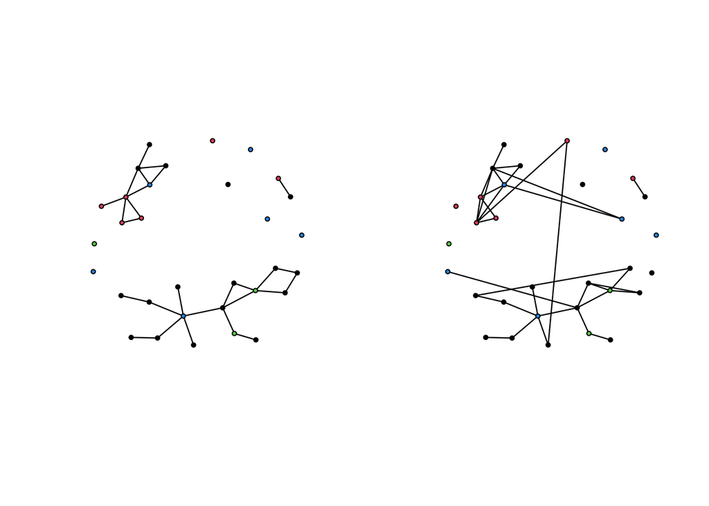

```r
par(mfrow=c(1,2))
coord <- plot( EIES1.net, vertex.col = EIESATT[,2] )
plot( EIES2.net, vertex.col = EIESATT[,2] , coord=coord )
```

## References

Everton, Sean F. 2012. *Disrupting Dark Networks*. 34. Cambridge University Press.

Hage, Per, and Frank Harary. 1983. *Structural Models in Anthropology*. Cambridge: Cambridge University Press.

Kapferer, Bruce. 1972. *Strategy and Transaction in an African Factory: African Workers and Indian Management in a Zambian Town*. Manchester University Press.

Koskinen, Johan H, Garry L Robins, Peng Wang, and Philippa E Pattison. 2013. “Bayesian Analysis for Partially Observed Network Data, Missing Ties, Attributes and Actors.” *Social Networks* 35 (4): 514–27.

Koskinen, Johan, Chiara Broccatelli, Peng Wang, and Garry Robins. 2017. “Bayesian Analysis of ERG Models for Multilevel, Multiplex, and Multilayered Networks with Sampled or Missing Data.” In *Convegno Della Società Italiana Di Statistica*, 105–17. Springer.

Koskinen, Johan, Peng Wang, Garry Robins, and Philippa Pattison. 2018. “Outliers and Influential Observations in Exponential Random Graph Models.” *Psychometrika* 83 (4): 809–30.

Mayo, Elton, Fritz Roethlisberger, and W Dickson. 1939. *Management and the Worker*. Cambridge, MA: Harvard University Press.

Padgett, John F, and Christopher K Ansell. 1993. “Robust Action and the Rise of the Medici, 1400-1434.” *American Journal of Sociology* 98 (6): 1259–319.

Read, Kenneth E. 1954. “Cultures of the Central Highlands, New Guinea.” *Southwestern Journal of Anthropology*, 1–43.

Sageman, Marc. 2011. *Understanding Terror Networks*. University of Pennsylvania press.

Webster, C. M. 1993. *Task-Related and Context-Based Constraints in Observed and Reported Relational Data*. Doctoral Dissertation, University of California, Irvine.

Zachary, Wayne W. 1977. “An Information Flow Model for Conflict and Fission in Small Groups.” *Journal of Anthropological Research* 33 (4): 452–73.